# Classification of media and countries

### Compute parameters

Salience of countries (p. 100,000)

| rnk | ISO3 | NAMEen | min | Q1 | Q2 | Q3 | mean | sd |
| --- | --- | --- | --- | --- | --- | --- | --- | --- |
| 1 | USA | United States of America | 7400 | 13743 | 15111 | 19988 | 16268 | 4451 |
| 2 | CHN | China | 1590 | 3382 | 4424 | 6943 | 5691 | 3544 |
| 4 | GBR | United Kingdom | 1140 | 2156 | 4210 | 5359 | 3858 | 1716 |
| 3 | RUS | Russia | 2372 | 3344 | 3892 | 5073 | 5291 | 5822 |
| 5 | SYR | Syria | 1312 | 2131 | 3293 | 4422 | 3606 | 1896 |
| 6 | FRA | France | 829 | 1948 | 2612 | 3481 | 2868 | 1303 |
| 7 | IRN | Iran | 427 | 1434 | 2065 | 2634 | 2399 | 2046 |
| 8 | DEU | Germany | 941 | 1340 | 1916 | 3054 | 2261 | 1148 |
| 10 | TUR | Turkey | 671 | 1087 | 1712 | 2494 | 2003 | 1123 |
| 9 | JPN | Japan | 652 | 1507 | 1703 | 2467 | 2045 | 1282 |
| 11 | ISR | Israel | 754 | 1199 | 1648 | 2305 | 1945 | 1068 |
| 13 | IND | India | 591 | 999 | 1317 | 1753 | 1655 | 1458 |
| 17 | ESP | Spain | 444 | 894 | 1269 | 2017 | 1489 | 823 |
| 12 | UKR | Ukraine | 512 | 910 | 1237 | 1584 | 1816 | 2621 |
| 14 | PRK | North Korea | 114 | 841 | 1157 | 1812 | 1636 | 1796 |
| 15 | IRQ | Iraq | 294 | 844 | 1153 | 1590 | 1567 | 1191 |
| 18 | AUS | Australia | 187 | 720 | 1084 | 1880 | 1421 | 1026 |
| 19 | BRA | Brazil | 106 | 850 | 1014 | 1559 | 1408 | 1148 |
| 20 | ITA | Italy | 365 | 809 | 1002 | 1676 | 1288 | 619 |
| 22 | EGY | Egypt | 439 | 732 | 880 | 1465 | 1116 | 595 |
| 16 | PSE | Palestinian Territories | 180 | 614 | 864 | 1485 | 1532 | 1641 |
| 23 | SAU | Saudi Arabia | 0 | 600 | 838 | 1206 | 1114 | 905 |
| 21 | KOR | South Korea | 235 | 544 | 764 | 1097 | 1202 | 1650 |
| 31 | NLD | Netherlands | 271 | 536 | 753 | 837 | 721 | 258 |
| 28 | CAN | Canada | 429 | 552 | 708 | 916 | 791 | 308 |
| 24 | PAK | Pakistan | 124 | 404 | 636 | 972 | 968 | 1596 |
| 30 | AFG | Afghanistan | 82 | 464 | 624 | 852 | 732 | 522 |
| 27 | ARG | Argentina | 227 | 373 | 604 | 785 | 851 | 803 |
| 26 | MEX | Mexico | 361 | 524 | 596 | 1165 | 949 | 655 |
| 29 | GRC | Greece | 169 | 475 | 574 | 886 | 788 | 577 |

[output cut: 171 more lines]

### Map of average salience

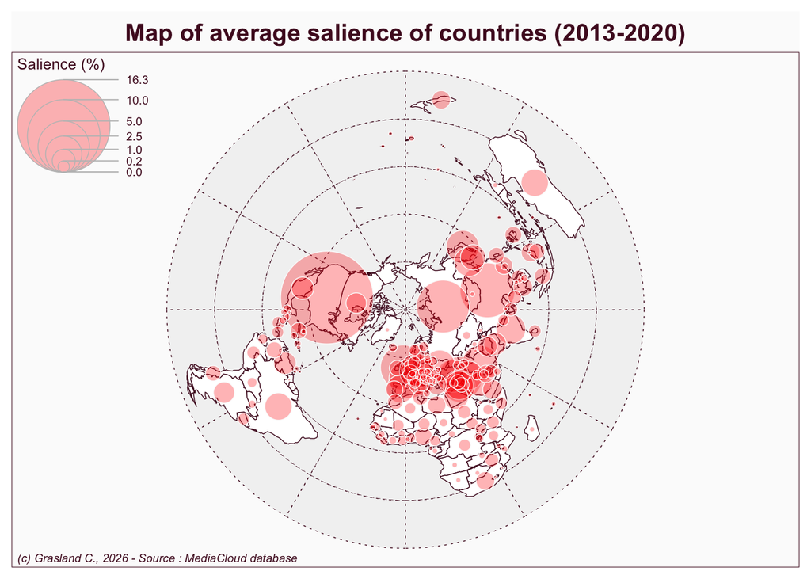

### Dorling cartogram

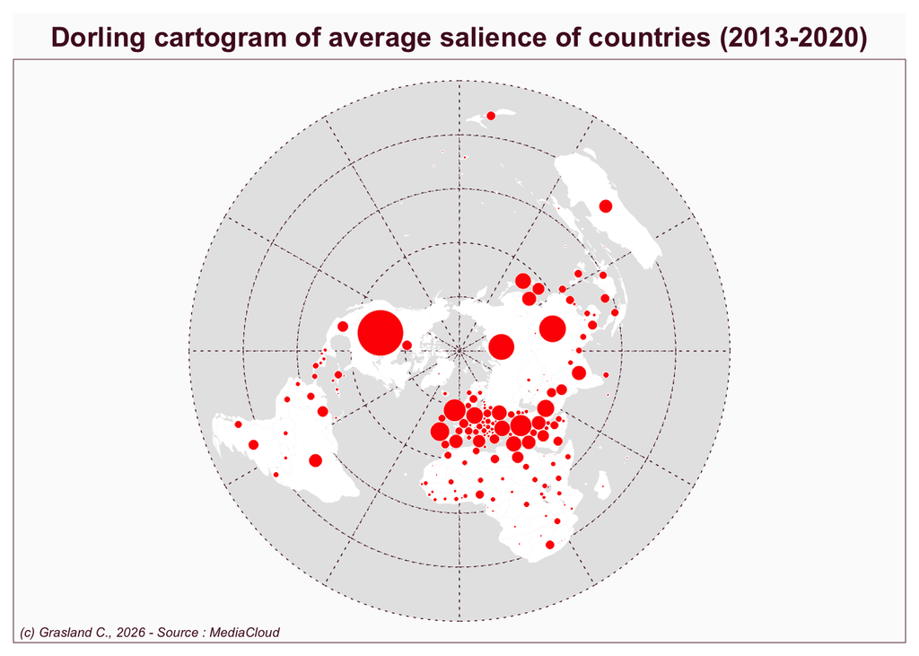

## Typology of media profiles

### Correlation matrix

We establish a correlation matrix based on the Spearman correlation coefficient based on rank. The rank correlation has been chosen against the classical Pearson coefficient because it is less influenced by the weight of top countries (USA, China, Russia, …) and is more likely to reval regional organisation of news at world scale.

The correlation are based after exclusion of the host countries (where media are located) . For example, the correlation between *Le Monde* and *Times of India* will exclude the salience of France and India from the vectors of values used for the measure of correlation.

Spearman correlation coefficient between median values

|  | ARG_nacion | AUS_sydmor | BRA_oglobo | CAN_tostar | CHN_mopost | DEU_frankf | DZA_alnaha | EGY_alwafd | ESP_abc | FRA_lmonde | GBR_indept | IDN_republ | IND_tindia | IRN_hamsha | ISR_jerpos | ITA_repubb | JPN_asahis | KEN_standa | MEX_inform | NGA_vangua | PAK_thenew | RUS_nezgaz | SGP_today | TUR_sabah | UKR_fakty | USA_nytime | ZAF_times |
| --- | --- | --- | --- | --- | --- | --- | --- | --- | --- | --- | --- | --- | --- | --- | --- | --- | --- | --- | --- | --- | --- | --- | --- | --- | --- | --- | --- |
| ARG_nacion | 1.00 | 0.63 | 0.86 | 0.70 | 0.57 | 0.72 | 0.43 | 0.47 | 0.85 | 0.61 | 0.73 | 0.57 | 0.58 | 0.58 | 0.58 | 0.69 | 0.65 | 0.33 | 0.91 | 0.42 | 0.62 | 0.54 | 0.61 | 0.59 | 0.57 | 0.72 | 0.42 |
| AUS_sydmor | 0.63 | 1.00 | 0.74 | 0.87 | 0.86 | 0.71 | 0.57 | 0.62 | 0.72 | 0.69 | 0.89 | 0.74 | 0.86 | 0.72 | 0.79 | 0.65 | 0.79 | 0.60 | 0.72 | 0.60 | 0.84 | 0.61 | 0.86 | 0.68 | 0.56 | 0.86 | 0.71 |
| BRA_oglobo | 0.86 | 0.74 | 1.00 | 0.81 | 0.70 | 0.81 | 0.62 | 0.63 | 0.92 | 0.76 | 0.81 | 0.69 | 0.72 | 0.72 | 0.76 | 0.82 | 0.73 | 0.54 | 0.93 | 0.61 | 0.75 | 0.63 | 0.79 | 0.71 | 0.61 | 0.85 | 0.61 |
| CAN_tostar | 0.70 | 0.87 | 0.81 | 1.00 | 0.79 | 0.83 | 0.64 | 0.70 | 0.83 | 0.80 | 0.90 | 0.70 | 0.84 | 0.77 | 0.86 | 0.76 | 0.78 | 0.65 | 0.81 | 0.66 | 0.82 | 0.71 | 0.87 | 0.77 | 0.67 | 0.96 | 0.73 |
| CHN_mopost | 0.57 | 0.86 | 0.70 | 0.79 | 1.00 | 0.68 | 0.54 | 0.59 | 0.66 | 0.64 | 0.79 | 0.73 | 0.85 | 0.71 | 0.73 | 0.57 | 0.80 | 0.53 | 0.66 | 0.53 | 0.79 | 0.58 | 0.84 | 0.64 | 0.50 | 0.80 | 0.62 |
| DEU_frankf | 0.72 | 0.71 | 0.81 | 0.83 | 0.68 | 1.00 | 0.63 | 0.72 | 0.84 | 0.78 | 0.84 | 0.66 | 0.71 | 0.80 | 0.81 | 0.84 | 0.71 | 0.51 | 0.78 | 0.61 | 0.76 | 0.78 | 0.78 | 0.85 | 0.78 | 0.83 | 0.57 |
| DZA_alnaha | 0.43 | 0.57 | 0.62 | 0.64 | 0.54 | 0.63 | 1.00 | 0.89 | 0.65 | 0.77 | 0.63 | 0.63 | 0.61 | 0.64 | 0.74 | 0.69 | 0.50 | 0.68 | 0.58 | 0.76 | 0.66 | 0.50 | 0.68 | 0.70 | 0.47 | 0.63 | 0.69 |
| EGY_alwafd | 0.47 | 0.62 | 0.63 | 0.70 | 0.59 | 0.72 | 0.89 | 1.00 | 0.69 | 0.77 | 0.70 | 0.67 | 0.68 | 0.75 | 0.82 | 0.70 | 0.56 | 0.63 | 0.62 | 0.68 | 0.72 | 0.64 | 0.74 | 0.79 | 0.57 | 0.70 | 0.64 |
| ESP_abc | 0.85 | 0.72 | 0.92 | 0.83 | 0.66 | 0.84 | 0.65 | 0.69 | 1.00 | 0.82 | 0.84 | 0.68 | 0.71 | 0.73 | 0.78 | 0.86 | 0.71 | 0.51 | 0.91 | 0.60 | 0.74 | 0.69 | 0.78 | 0.78 | 0.69 | 0.85 | 0.59 |
| FRA_lmonde | 0.61 | 0.69 | 0.76 | 0.80 | 0.64 | 0.78 | 0.77 | 0.77 | 0.82 | 1.00 | 0.78 | 0.68 | 0.67 | 0.70 | 0.78 | 0.83 | 0.61 | 0.71 | 0.73 | 0.80 | 0.73 | 0.58 | 0.78 | 0.75 | 0.56 | 0.80 | 0.75 |
| GBR_indept | 0.73 | 0.89 | 0.81 | 0.90 | 0.79 | 0.84 | 0.63 | 0.70 | 0.84 | 0.78 | 1.00 | 0.75 | 0.84 | 0.78 | 0.86 | 0.80 | 0.76 | 0.61 | 0.78 | 0.63 | 0.87 | 0.72 | 0.85 | 0.81 | 0.71 | 0.91 | 0.70 |
| IDN_republ | 0.57 | 0.74 | 0.69 | 0.70 | 0.73 | 0.66 | 0.63 | 0.67 | 0.68 | 0.68 | 0.75 | 1.00 | 0.73 | 0.72 | 0.76 | 0.67 | 0.68 | 0.58 | 0.68 | 0.60 | 0.75 | 0.59 | 0.79 | 0.71 | 0.53 | 0.73 | 0.65 |
| IND_tindia | 0.58 | 0.86 | 0.72 | 0.84 | 0.85 | 0.71 | 0.61 | 0.68 | 0.71 | 0.67 | 0.84 | 0.73 | 1.00 | 0.74 | 0.81 | 0.67 | 0.77 | 0.61 | 0.68 | 0.58 | 0.87 | 0.63 | 0.86 | 0.71 | 0.58 | 0.84 | 0.68 |
| IRN_hamsha | 0.58 | 0.72 | 0.72 | 0.77 | 0.71 | 0.80 | 0.64 | 0.75 | 0.73 | 0.70 | 0.78 | 0.72 | 0.74 | 1.00 | 0.85 | 0.74 | 0.74 | 0.48 | 0.69 | 0.53 | 0.81 | 0.82 | 0.79 | 0.87 | 0.72 | 0.80 | 0.54 |
| ISR_jerpos | 0.58 | 0.79 | 0.76 | 0.86 | 0.73 | 0.81 | 0.74 | 0.82 | 0.78 | 0.78 | 0.86 | 0.76 | 0.81 | 0.85 | 1.00 | 0.76 | 0.71 | 0.63 | 0.73 | 0.65 | 0.84 | 0.78 | 0.90 | 0.88 | 0.67 | 0.89 | 0.67 |
| ITA_repubb | 0.69 | 0.65 | 0.82 | 0.76 | 0.57 | 0.84 | 0.69 | 0.70 | 0.86 | 0.83 | 0.80 | 0.67 | 0.67 | 0.74 | 0.76 | 1.00 | 0.64 | 0.56 | 0.77 | 0.66 | 0.73 | 0.69 | 0.74 | 0.80 | 0.71 | 0.76 | 0.60 |
| JPN_asahis | 0.65 | 0.79 | 0.73 | 0.78 | 0.80 | 0.71 | 0.50 | 0.56 | 0.71 | 0.61 | 0.76 | 0.68 | 0.77 | 0.74 | 0.71 | 0.64 | 1.00 | 0.48 | 0.71 | 0.49 | 0.77 | 0.63 | 0.80 | 0.65 | 0.56 | 0.79 | 0.57 |
| KEN_standa | 0.33 | 0.60 | 0.54 | 0.65 | 0.53 | 0.51 | 0.68 | 0.63 | 0.51 | 0.71 | 0.61 | 0.58 | 0.61 | 0.48 | 0.63 | 0.56 | 0.48 | 1.00 | 0.47 | 0.90 | 0.59 | 0.29 | 0.67 | 0.48 | 0.24 | 0.63 | 0.94 |
| MEX_inform | 0.91 | 0.72 | 0.93 | 0.81 | 0.66 | 0.78 | 0.58 | 0.62 | 0.91 | 0.73 | 0.78 | 0.68 | 0.68 | 0.69 | 0.73 | 0.77 | 0.71 | 0.47 | 1.00 | 0.55 | 0.71 | 0.61 | 0.74 | 0.68 | 0.59 | 0.83 | 0.56 |
| NGA_vangua | 0.42 | 0.60 | 0.61 | 0.66 | 0.53 | 0.61 | 0.76 | 0.68 | 0.60 | 0.80 | 0.63 | 0.60 | 0.58 | 0.53 | 0.65 | 0.66 | 0.49 | 0.90 | 0.55 | 1.00 | 0.64 | 0.35 | 0.67 | 0.56 | 0.34 | 0.64 | 0.88 |
| PAK_thenew | 0.62 | 0.84 | 0.75 | 0.82 | 0.79 | 0.76 | 0.66 | 0.72 | 0.74 | 0.73 | 0.87 | 0.75 | 0.87 | 0.81 | 0.84 | 0.73 | 0.77 | 0.59 | 0.71 | 0.64 | 1.00 | 0.69 | 0.85 | 0.79 | 0.65 | 0.83 | 0.69 |
| RUS_nezgaz | 0.54 | 0.61 | 0.63 | 0.71 | 0.58 | 0.78 | 0.50 | 0.64 | 0.69 | 0.58 | 0.72 | 0.59 | 0.63 | 0.82 | 0.78 | 0.69 | 0.63 | 0.29 | 0.61 | 0.35 | 0.69 | 1.00 | 0.69 | 0.85 | 0.91 | 0.72 | 0.36 |
| SGP_today | 0.61 | 0.86 | 0.79 | 0.87 | 0.84 | 0.78 | 0.68 | 0.74 | 0.78 | 0.78 | 0.85 | 0.79 | 0.86 | 0.79 | 0.90 | 0.74 | 0.80 | 0.67 | 0.74 | 0.67 | 0.85 | 0.69 | 1.00 | 0.78 | 0.59 | 0.91 | 0.74 |
| TUR_sabah | 0.59 | 0.68 | 0.71 | 0.77 | 0.64 | 0.85 | 0.70 | 0.79 | 0.78 | 0.75 | 0.81 | 0.71 | 0.71 | 0.87 | 0.88 | 0.80 | 0.65 | 0.48 | 0.68 | 0.56 | 0.79 | 0.85 | 0.78 | 1.00 | 0.81 | 0.78 | 0.54 |
| UKR_fakty | 0.57 | 0.56 | 0.61 | 0.67 | 0.50 | 0.78 | 0.47 | 0.57 | 0.69 | 0.56 | 0.71 | 0.53 | 0.58 | 0.72 | 0.67 | 0.71 | 0.56 | 0.24 | 0.59 | 0.34 | 0.65 | 0.91 | 0.59 | 0.81 | 1.00 | 0.65 | 0.33 |
| USA_nytime | 0.72 | 0.86 | 0.85 | 0.96 | 0.80 | 0.83 | 0.63 | 0.70 | 0.85 | 0.80 | 0.91 | 0.73 | 0.84 | 0.80 | 0.89 | 0.76 | 0.79 | 0.63 | 0.83 | 0.64 | 0.83 | 0.72 | 0.91 | 0.78 | 0.65 | 1.00 | 0.71 |
| ZAF_times | 0.42 | 0.71 | 0.61 | 0.73 | 0.62 | 0.57 | 0.69 | 0.64 | 0.59 | 0.75 | 0.70 | 0.65 | 0.68 | 0.54 | 0.67 | 0.60 | 0.57 | 0.94 | 0.56 | 0.88 | 0.69 | 0.36 | 0.74 | 0.54 | 0.33 | 0.71 | 1.00 |

### Principal Component Analysis

The PCA provide a first viusalization of the proximity between media and some clustrs can be easily observed on the plan defined by the two first component. It is a simple approximation and better results could be obtained with Multi Dimensional Scaling (MDS) or Network Analysis (it will be done later).

[interactive chart not shown]

- **Comment** : The figure reveals immediately a clustering of media based on geographical or language proximity. Notice the specific situation of the french media *Le Monde* in an intermediate position between media from Western Europe and media from Northern Africa.